# homework

19074

2019-12-30

# HW 2019-09-23

## Question

Use knitr to produce at least 3 examples(texts,figures,tables).

## Answer 1: Text

### 1.1 Introduction

Here we will introduce a clustering algorithm which is called $K-Means$. Suppose that there is a dataset which may comes from different populations, we’ll find a way to divide them into k clusters, the greater the similarity within the group, the greater the difference between groups, the better the clustering effect.

### 1.2 Algorithm

Suppose that the dataset is $\left\{x^{(1)}, \ldots, x^{(m)}\right\}$, for each $x^{(i)} \in \mathbb{R}^{n}$, and we want to assign them to K clusters.

The specific algorithm is as follows:

1. Select K cluster centriods randomly, $\mu_{1}, \mu_{2}, \ldots, \mu_{k} \in \mathbb{R}^{n}$;
2. Repeat the following process until converged:
- For each sample i, calculate the cluster to which it should belong, $c^{(i)} :=\arg \min _{j}\left\|x^{(i)}-\mu_{j}\right\|^{2}$;
- For each cluster j, recalculate the centriod of that cluster, $\mu_{j} :=\frac{\sum_{i=1}^{m} 1\left\{c^{(i)}=j\right\} x^{(i)}}{\sum_{i=1}^{m} 1\left\{c^{(i)}=j\right\}}$.

## Answer 2: Figure

### 2.1 Generate a Dataset and visualize

In this section, we will create a dataset and visualize the data.

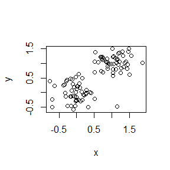

```r
# Create two groups of points from two different populations
datatest <- rbind(matrix(rnorm(100, sd = 0.3), ncol = 2),
           matrix(rnorm(100, mean = 1, sd = 0.3), ncol = 2))
colnames(datatest) <- c("x", "y")

# Visualize the data
plot(datatest)
```

### 2.2 Cluster and visualize

Next, we divide the dataset into two clusters with kmeans function. After clustering, visualize the clusters winch helps present the clustering effects more intuitively.

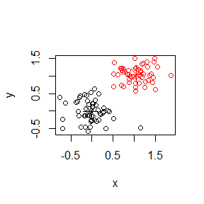

```r
# Use K-means clustering to divide the whole group into two clusters
kmeanscluster <- kmeans(datatest, 2)

# Visualize the clusters
plot(datatest, col = kmeanscluster$cluster)
points(kmeanscluster$centers, col = 1 : 2, pch = 8, cex = 2)
```

## Answer 3: Table

Finally, we’ll have a look at a dataset called state.x77 which is related to the 50 states of the United States of America. We may be interested in the relevance of these data, and we get their correlation coefficient matrix with the cor function and present the results in a table.

```r
y <- cor(state.x77)
library(knitr)
kable(head(y), format = "html")
```

|  | Population | Income | Illiteracy | Life Exp | Murder | HS Grad | Frost | Area |
| --- | --- | --- | --- | --- | --- | --- | --- | --- |
| Population | 1.0000000 | 0.2082276 | 0.1076224 | -0.0680520 | 0.3436428 | -0.0984897 | -0.3321525 | 0.0225438 |
| Income | 0.2082276 | 1.0000000 | -0.4370752 | 0.3402553 | -0.2300776 | 0.6199323 | 0.2262822 | 0.3633154 |
| Illiteracy | 0.1076224 | -0.4370752 | 1.0000000 | -0.5884779 | 0.7029752 | -0.6571886 | -0.6719470 | 0.0772611 |
| Life Exp | -0.0680520 | 0.3402553 | -0.5884779 | 1.0000000 | -0.7808458 | 0.5822162 | 0.2620680 | -0.1073319 |
| Murder | 0.3436428 | -0.2300776 | 0.7029752 | -0.7808458 | 1.0000000 | -0.4879710 | -0.5388834 | 0.2283902 |
| HS Grad | -0.0984897 | 0.6199323 | -0.6571886 | 0.5822162 | -0.4879710 | 1.0000000 | 0.3667797 | 0.3335419 |

# HW 2019-09-29

## 1 Question : exercise 3.4 From Page 74

The Rayleigh density [156, Ch.18] is
$$f(x)=\frac{x}{\sigma^{2}} e^{-x^{2} /\left(2 \sigma^{2}\right)}, \quad x \geq 0, \sigma>0.$$
Develop an algorithm to generate random samples from a Rayleigh(σ) distribution. Generate Rayleigh(σ) samples for several choices of σ>0 and check that the mode of the generated samples is close to the theoretical mode σ (check the histogram).

## 1.1 Answer : the acceptance-rejection methood

Here we assign $g(x)$ to be the pdf of Gamma(2,$1/\sigma^2$), and c is $Gamma\left(2\right)\sigma^4e^{1/2\sigma^2}$.

In this exercise, we choose $\sigma^2$ to be 1, 4, 0.25, 16.

### 1.1.1 Sampling function via the acceptance-rejection methood

```r
# generate n r.v. from f(x) with sigma2
rRayleigh <- function(n, sigma2){
  j<-k<-0
  y <- numeric(n)
  while (k < n) {
  u <- runif(1)
  j <- j + 1
  x <- rgamma(1,shape = 2,scale = sigma2) # random variate from g
  if (exp(-(x^2-2*x+1)/(2*sigma2)) > u) {
    #we accept x
    k <- k + 1
    y[k] <- x
    }
  }
  hist(y, prob = TRUE)
  y <- seq(0, 20, .002)
  lines(y, y*exp(-y^2/(2*sigma2))/sigma2)
}
```

### 1.1.2 $\sigma^2=1$

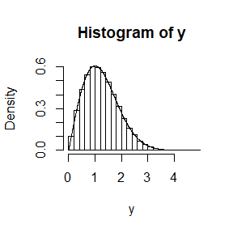

```r
rRayleigh(100000,1)
```

### 1.1.3 $\sigma^2=4$

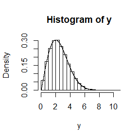

```r
rRayleigh(100000,4)
```

### 1.1.4 $\sigma^2=0.25$

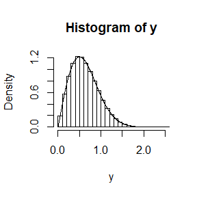

```r
rRayleigh(100000,0.25)
```

### 1.1.5 $\sigma^2=16$

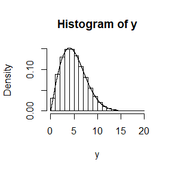

```r
rRayleigh(100000,16)
```

## 1.2 Analysis of the result of exercise 3.4

From the histogram, it is easy to find that the simulated sampling obtained by the acceptance-rejection method is very close to the real Rayleigh distribution sampling result, which can indicate that we have obtained the result with good performance. Further, we can also check that the mode σ of the generated samples is close to the theoretical mode σ.

## 2 Question : exercise 3.11 from page 75

Generate a random sample of size 1000 from a normal location mixture. The components of the mixture have N(0,1)and N(3,1)distributions with mixing probabilities p1 and p2 =1−p1. Graph the histogram of the sample with density superimposed, for p1 =0.75. Repeat with diﬀerent values for p1 and observe whether the empirical distribution of the mixture appears to be bimodal. Make a conjecture about the values of p1 that produce bimodal mixtures.

## 2.1 Answer : Transformation methods

### 2.1.1 Sampling function via transformation methods

```r
normlocationmixture <- function(n, p){
  x1 <- rnorm(n, 0, 1)
  x2 <- rnorm(n, 3, 1)
  r <- rbinom(n, 1, p)
  z <- r*x1+(1-r)*x2
  hist(z, probability = TRUE)
  z <- seq(-5, 10, .001)
  lines(z,p*dnorm(z,0,1)+(1-p)*dnorm(z,3,1))
}
```

### 2.1.2 p1=0.75

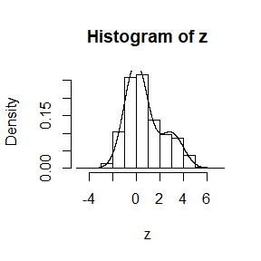

```r
normlocationmixture(10000, 0.75)
```

### 2.1.3 Try different values of p1

```r
p <- seq(0.05,1,.05)
for (i in c(1:20)){
  normlocationmixture(10000,p[i])
  print(p[i])
}
```

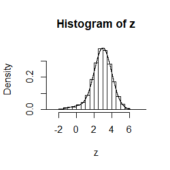

```
## [1] 0.05
```

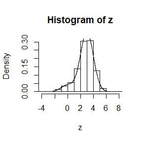

```
## [1] 0.1
```

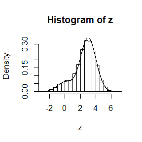

```
## [1] 0.15
```

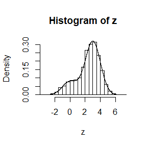

```
## [1] 0.2
```

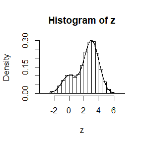

```
## [1] 0.25
```

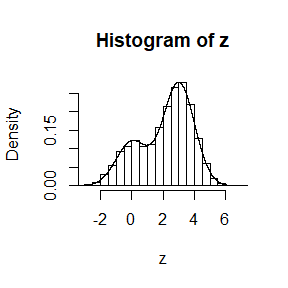

```
## [1] 0.3
```

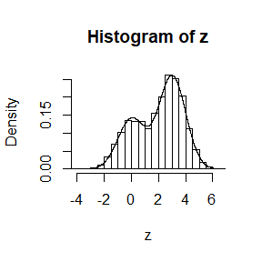

```
## [1] 0.35
```

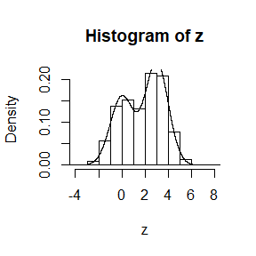

```
## [1] 0.4
```

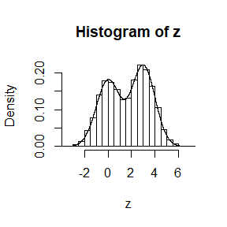

```
## [1] 0.45
```

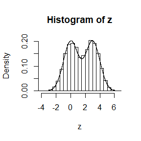

```
## [1] 0.5
```

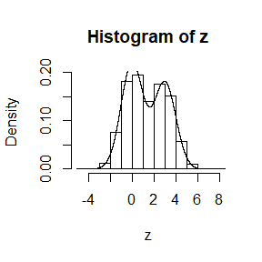

```
## [1] 0.55
```

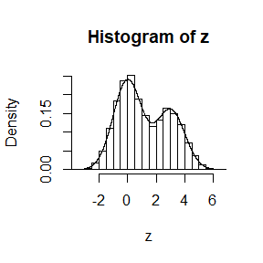

```
## [1] 0.6
```

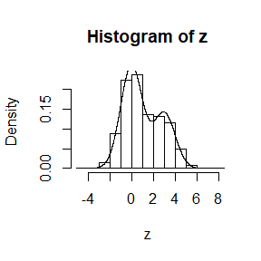

```
## [1] 0.65
```

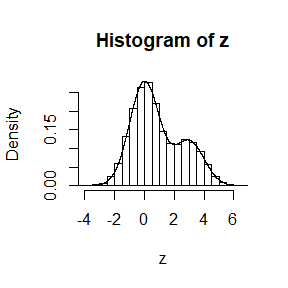

```
## [1] 0.7
```

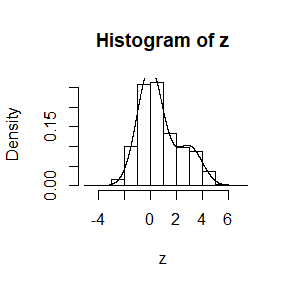

```
## [1] 0.75
```

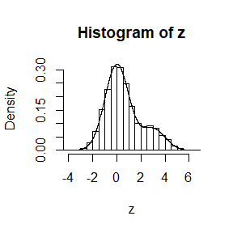

```
## [1] 0.8
```

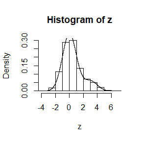

```
## [1] 0.85
```

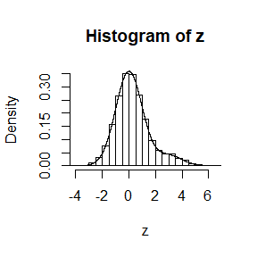

```
## [1] 0.9
```

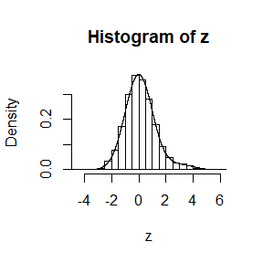

```
## [1] 0.95
```

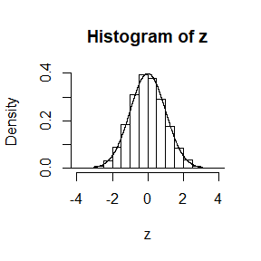

```
## [1] 1
```

## 2.2 Analysis of the result of exercise 3.11

By taking different values of p1, we find that in some cases there will be bimodal mixture. Through experiments, an approximate guess can be made that when 0.25<p1<0.75, bimodal mixture will occur.

## 3 Question : exercise 3.18 from page 76

Write a function to generate a random sample from a Wd(Σ,n) (Wishart) distribution for n>d+1≥1, based on Bartlett’s decomposition.

## 3.1 Answer : Wishart distribution based on Bartlett’s decomposition

Notice that here we are required to sample from Wishart distribution based on Bartlett’s decomposition. However, it’s easy to find that generating a sample by its definition is much more convenient. So, in this exercise both method will be implemented.

### 3.1.1 Sampling function via Bartlett’s decomposition

```r
Wdsampling1 <- function(Sigma, d, n){
  library(MASS)
  L <- chol(Sigma) # Sigma=LL'
  T <- matrix(0, nrow = d, ncol = d)
  for (i in (1:d)){
    T[i,i] <- sqrt(rchisq(1,n-i+1))
    for (j in 1:i-1){
      T[i,j] <- rnorm(1)
    }
  }
  S <- L%*%T%*%t(T)%*%t(L)  #Bartlett's decomposition
  S
}
```

### 3.1.2 Generate a sample

```r
Wdsampling1(diag(3)+1, 3, 5)
```

```
##           [,1]     [,2]     [,3]
## [1,] 34.058367 4.588837 8.324221
## [2,]  4.588837 6.456476 4.279184
## [3,]  8.324221 4.279184 5.743764
```

### 3.1.3 Sampling function via its definition

This method is from https://www.datalearner.com/blog/1051508471131357.

```r
Wdsampling2 <- function(Sigma, d, n){
  library(MASS)
  Id <- diag(d)
  Md <- numeric(d)
  x <- mvrnorm(n, Md, Id)  #x[i,]~N(0,Id)
  L <- chol(Sigma)
  for (i in (1:n)){
      A <- x[i,]%*%t(x[i,])
  } # generate a wishart(Id,d,n) sample
  S <- L%*%A%*%t(L)
  S
}
```

### 3.1.4 Generate a sample

```r
Wdsampling2(diag(3)+1, 3, 5)
```

```
##            [,1]       [,2]       [,3]
## [1,]  0.1019454 -0.1193462  0.3055799
## [2,] -0.1193462  0.1397171 -0.3577384
## [3,]  0.3055799 -0.3577384  0.9159711
```

# HW 2019-10-11

## 1 Question 1 : exercise 5.1

Compute a Monte Carlo estimate of $\int_0^{\frac{\pi}{3}} sint dt$.

## 1.1 Answer

According to $\int_0^{\frac{\pi}{3}} sint dt=\frac{\pi}{3}E\left(sint\right),t\sim U\left(0,\frac{\pi}{3}\right)$ , we can calculate it as below.

```r
m <- 1e4   # number of samplings
t <- runif(m, min=0, max=pi/3)   # generate samples from U(0,pi/3)
theta.hat <- mean(sin(t)) * pi/3  # calculate theta.hat
print(c(theta.hat,0.5))  # check it vs the true value
```

```
## [1] 0.5058131 0.5000000
```

## 1.2 Analysis of the result

It’s easy to find that when the number of samplings is 10000, a Monte Carlo estimate of $\int_0^{\frac{\pi}{3}} sint dt$ is 0.5058131, which is close to the true value of it.

## 2 Question 2 : exercise 5.10

Use Monte Carlo integration with antithetic variables to estimate $\int_0^1\frac{e^{-x}}{\left(1+x^2\right)} dx$, and ﬁnd the approximatereduction in varianceas a percentage of the variance without variance reduction.

## 2.1 Answer : Antithetic variables

- step 1 : set the number of sampling $n$
- step 2 : generate $\frac n2$ samples from U(0,1), $x_1,x_2,…,x_{\frac n2}$
- step 3 : estimate it as $\hat\theta=\frac1n\sum_{j=1}^{n/2}\left(\frac {e^\left(-x_j\right)}{1+x_j^2}+\frac {e^\left(-1+x_j\right)}{1+(1-x_j)^2}\right)$, $U_j\sim U(0,x)$

```r
n <- 1e4   # number of samplings
x <- runif(n/2, min=0, max=1)   # generate n/2 samples from U(0,1)
y <- 1-x
u <- exp(-x)/(1+x^2)
v <- exp(-y)/(1+y^2)
theta1.hat <- (mean(u)+mean(v))/2
sd1.hat <- sd((u+v)/2)
# estimate it with antithetic variables
x1 <- runif(n, min=0, max=1)
u1 <- exp(-x1)/(1+x1^2)
theta2.hat <- mean(u1)
sd2.hat <- sd(u1)
# estimate it without variance reduction
re.sd <- (sd2.hat-sd1.hat)/sd2.hat  #the approximate reduction in varianceas
print(re.sd)
```

```
## [1] 0.8639797
```

## 3 Question 3 : exercise 5.15

Obtain the stratiﬁed importance sampling estimate in Example 5.13 and compare it with the result of Example 5.10.

Example 5.13 (Example 5.10, cont.) In Example 5.10,our best result was obtained with importance function $f_3(x)= e^\left(−x\right)/(1−e^\left(−1\right))$,$0<x<1$. From 10000 replicates we obtained the estimate $\widehat\theta =0 .5257801$ and an estimated standard error 0.0970314. Now divide the interval (0,1) into ﬁve subintervals,$(j/5,(j +1)/5)$, $j =0 ,1,...,4$. Then on the $j$th subinterval variables are generated from the density
$$\frac {5e^\left(-x\right)}{1-e^\left(-1\right)},\frac{j-1}{5}<x<\frac j5.$$
The implementation is left as an exercise.

Example 5.10 (Choice of the importance function) In this example (from [64, p. 728]) several possible choices of importance functions to estimate $\int_0^1\frac{e^{-x}}{\left(1+x^2\right)} dx$ by importance sampling method are compared. The candidates for the importance functions are
$$f_0(x)=1,0<x<1,$$
$$f_1(x)=e^\left(-x\right),0<x<\infty,$$
$$f_2(x)=(1+x^2)^\left(-1\right)/\pi,-\infty<x<\infty,$$
$$f_3(x)=\frac {e^\left(-x\right)}{1-e^\left(-1\right)},0<x<1,$$
$$f_4(x)=4(1+x^2)^\left(-1\right)/\pi,0<x<1$$

## 3.0 Preface

**Notice that 3.1 sections is computed according to the requirement of Example 5.13, and 3.2 section is computed as stated in page 147.** **也即3.1部分按照例13的要求计算，3.2部分按照课本p147的方法计算.**

## 3.1 Answer

### 3.1.1 Example 5.10 : Importance function

- step 1 : set number of samples $m$
- step 2 : generate samples $x_1,x_2,…,x_m$ from $f$
- step 3 : estimate it as $\hat\theta=\frac1m\sum_{i=1}^m\frac{g(X_i)}{f(X_i)}$

```r
m <- 10000
theta.hat <- se <- numeric(5)

g <- function(x) {
  exp(-x - log(1+x^2)) * (x > 0) * (x < 1)
}

x <- runif(m) #using f0
fg <- g(x)
theta.hat[1] <- mean(fg)
se[1] <- sd(fg)

x <- rexp(m, 1) #using f1
fg <- g(x) / exp(-x)
theta.hat[2] <- mean(fg)
se[2] <- sd(fg)

x <- rcauchy(m) #using f2
i <- c(which(x > 1), which(x < 0))
x[i] <- 2 #to catch overflow errors in g(x)
fg <- g(x) / dcauchy(x)
theta.hat[3] <- mean(fg)
se[3] <- sd(fg)

u <- runif(m) #f3, inverse transform method
x <- - log(1 - u * (1 - exp(-1)))
fg <- g(x) / (exp(-x) / (1 - exp(-1)))
theta.hat[4] <- mean(fg)
se[4] <- sd(fg)

u <- runif(m) #f4, inverse transform method
x <- tan(pi * u / 4)
fg <- g(x) / (4 / ((1 + x^2) * pi))
theta.hat[5] <- mean(fg)
se[5] <- sd(fg)

res <- rbind(theta=round(theta.hat,3), se=round(se,3))
colnames(res) <- paste0('f',0:4)
knitr::kable(res, format = "html",align='c')
```

|  | f0 | f1 | f2 | f3 | f4 |
| --- | --- | --- | --- | --- | --- |
| theta | 0.523 | 0.523 | 0.536 | 0.525 | 0.526 |
| se | 0.245 | 0.418 | 0.957 | 0.097 | 0.142 |

### 3.1.2 Example 5.13 ： stratiﬁed importance sampling estimate

To solve this problem, I’ll follow the exercise description method to implement.

- step 1 : divide the real line into k intervals $(j/5,(j +1)/5)$, $j =0 ,1,...,4$
- step 2 : for each subinterval $g_j(x)=g(x)I_{(j/5,(j +1)/5]}(x),j=1,2,…,k$
- step 3 : for each subinterval $f_j(x)=\frac{1-e^\left(-1\right)}{e^\left(-\frac{i}{k}\right)-e^\left(-\frac{i+1}{k}\right)}f(x),x\in (j/5,(j +1)/5]$
- step 4 : estimate $\theta_j=\int_{\frac j5}^{\frac{j+1}5}g_j(x)dx$ via importance function $f_j(x)$
- step 5 : estimate it as $\theta=\sum_{j=1}^k\theta_j$

```r
M <- 10000
k <- 5
N <- 50

a <- (seq(k+1)-1)/k

g<-function(x)exp(-x)/(1+x^2)*(x>0)*(x<1)

kcof <- function(i){
  ans <- (1-exp(-1))/(exp(-(i-1)/k)-exp(-i/k))
  ans
}

st.im <- function(i){
  u <- runif(M/k)   # inverse transformation method
  v <- - log(exp(-(i-1)/k)-(exp(-(i-1)/k)-exp(-i/k))*u)
  fg <- g(v)/(kcof(i)*exp(-v)/(1-exp(-1)))
  fg
}
est <- matrix(0,N,2)
for (i in 1:N){
  for (j in 1:k){
    uu <- st.im(j)
    est[i,1] <- est[i,1]+mean(uu)
    est[i,2] <- est[i,2]+sd(uu)
  }
}
ans <- rbind(apply(est,2,mean),apply(est,2,sd))
colnames(ans) <- c('mean','sd')
library(knitr)
knitr::kable(ans,format='html')
```

| mean | sd |
| --- | --- |
| 0.5247914 | 0.0169723 |
| 0.0001896 | 0.0000787 |

### 3.1.3 Analysis

By comparing the results of importance estimation and stratified importance estimation, we can find that the variance of stratified importance estimation is 0.0169723 which is about 1/5 of the variance of the importance sampling.

## 3.2 Another way for stratified importance estimation

As it’s stated in Chap 5.8, I’ll divide the interval in another way.

- step 1 : divide the real line into k intervals $I_j=[a_{j-1},a_j),j=1,2,…,k$ where $a_j=F^{-1}(\frac jk)=-ln(1-\frac j5(1-e^{-1})),j=1,2,…,k-1$ and $a_0=-\infty,a_k=\infty$
- step 2 : for each subinterval $g_j(x)=g(x)I_{[a_{j-1},a_j)}(x),j=1,2,…,k$
- step 3 : for each subinterval $f_j(x)=kf(x),x\in I_j$
- step 4 : estimate $\theta_j=\int_{a_{j-1}}^{a_j}g_j(x)dx$ via importance function $f_j(x)$
- step 5 : estimate it as $\theta=\sum_{j=1}^k\theta_j$

```r
M <- 10000
k <- 5
N <- 50

a <- numeric(k+1)
for (l in 2:k)
  a[l]=-log(1-(l-1)*(1-exp(-1))/k)
a[k+1] <- 1
a[1] <- 0
# divide the real line into k intervals

g<-function(x)exp(-x)/(1+x^2)*(x>0)*(x<1)
# integrated function

st.im <- function(lower,upper){
  u <- runif(M/k)   # inverse transformation method
  v <- -log(exp(-lower)-(1-exp(-1))*u/k)
  fg <- g(v)/(k*exp(-v)/(1-exp(-1)))
  fg
}
# samples from interval [lower,upper)

est <- matrix(0,N,2)
for (i in 1:N){
  for (j in 1:k){
    uu <- st.im(a[j],a[j+1])
    est[i,1] <- est[i,1]+mean(uu)
    est[i,2] <- est[i,2]+sd(uu)
  }
}
ans <- rbind(apply(est,2,mean),apply(est,2,sd))
colnames(ans) <- c('mean','sd')
library(knitr)
knitr::kable(ans,format='html')
```

| mean | sd |
| --- | --- |
| 0.5247542 | 0.0183119 |
| 0.0001983 | 0.0001009 |

We can find that the variance is 0.0183119,which approximates the variance of another way.

# HW 2019-10-18

## Question : Exercise 6.5

- Suppose a $95\%$ symmetric t-interval is applied to estimate a mean, but the sample data are non-normal. Then the probability that the conﬁdence interval covers the mean is not necessarily equal to $0.95$.
- Use a Monte Carlo experiment to estimate the coverage probability of the t-interval for random samples of $\chi^2(2)$ data with sample size $n=20$.
- Compare your t-interval results with the simulation results in Example 6.4.(The t-interval should be more robust to departures from normality than the interval for variance.)

## Answer

**Monte Carlo experiment to estimate a conﬁdence level**

- Suppose that $X \sim F_X$ is the random variable of interest and that $\theta$ is the target parameter to be estimated.
  - 1.For each replicate, indexed $i=1,...,m$ :
    - (a)Generate the jth random sample, $X^{(i)}=(X^{(i)}_1 ,...,X^{(i)}_n)$.
    - (b)Compute the conﬁdence interval $C_i$ for the jth sample.
    - (c)Compute $y_i=I(\theta\in C_i)$ for thejth sample.
  - 2.Compute the empirical conﬁdence level $\bar y=\frac1m\sum_{i=1}^my_i$.
- In this exercise:
  - $C_i=(\bar X^{(i)}+t_{\alpha/2}(n-1)sd(X^{(i)})/\sqrt n,\bar X^{(i)}+t_{1-\alpha/2}(n-1)sd(X^{(i)})/\sqrt n)$
  - $E(\chi^2(v))=v$

```r
ecp.chi2 <- function(n, m, v, alpha){
  # coverage probability of CI,sample size n,replicate m,confidence level 1-alpha
  ecp <- numeric(m)
  for(i in 1:m){
    x <- rchisq(n, df = v) # sample from chi(v)
    lcl <- mean(x) - qt(1-alpha/2, n-1) * sd(x) / sqrt(n) # lower conﬁdence limit
    ucl <- mean(x) + qt(1-alpha/2, n-1) * sd(x) / sqrt(n) # upper conﬁdence limit
    if(lcl <= v){
        if(v <= ucl){
          ecp[i] <- 1
        }
    } # cp for a MC experiment replicate
  }
  cp <- mean(ecp)
  cp
}
ecp <- ecp.chi2(20, 1000, 2, 0.05)
ecp
```

```
## [1] 0.921
```

**Simulation results in Example 4**

```r
n <- 20
alpha <- .05
UCL <- replicate(1000, expr = {
  x <- rchisq(n, df = 2)
  (n-1) * var(x) / qchisq(alpha, df = n-1)
  })
ecp.eg4 <- mean(UCL > 4)
```

**Analysis**

- The empirical conﬁdence level is 0.921 in this experiment. In this experiment the interval for variance, from Page 162, only 0.783 of the intervals contained the population variance, which is far from the $0.95$ coverage under normality.
- The t-interval is more robust to departures from normality than the interval for variance.

## Question 2 : Exercise 6.6

- Estimate the $0.025$, $0.05$, $0.95$, and $0.975$ quantiles of the skewness $\sqrt {b_1}$ under normality by a Monte Carlo experiment.
- Compute the standard error of the estimates from (2.14) using the normal approximation for the density (with exact variance formula).
- Compare the estimated quantiles with the quantiles of the large sample approximation $\sqrt {b_1}\sim N(0,\frac 6n)$.

## Answer

- 1.For each replicate, indexed $i=1,...,m$ :
  - (a)Generate the jth random sample, $X^{(i)}=(X^{(i)}_1 ,...,X^{(i)}_n)$.
  - (b)Compute the skewness $\sqrt{b_1^{(j)}}=\frac{\frac1n\sum_{j=1}^m(X^{(i)}_j-\bar X_{.}^{(i)})^3}{(\frac1n\sum_{j=1}^m(X^{(i)}_j-\bar X_{.}^{(i)})^2)^{(\frac32)}}$.
- 2.Compute the quantile of $\sqrt{b_1}$.
- 3.Compute the standard error of the estimates $Var(\hat X_q)=\frac {q(1-q)}{nf(X_q)^2}$, where $f(X_q)$ is pdf of $N(0,\frac{6(n-2)}{(n+1)(n+3)})$

```r
sk <- function(x) {
  #computes the sample skewness coeff.
  xbar <- mean(x)
  m3 <- mean((x - xbar)^3)
  m2 <- mean((x - xbar)^2)
  return(m3 / m2^1.5)
}

MC_sk <- function(n, m){
  #a MC experiment of m replicate,with n sample from population
  #estimate skewness of each replicate
  MC_skewness <- numeric(m)
  for (i in 1:m){
    replicate_MC <- rnorm(n)
    MC_skewness[i] <- sk(replicate_MC)
  }
  MC_skewness
}

level <- c(0.025, 0.05, 0.95, 0.975)
n <- 20
m <- 1000
q_sk <- quantile(MC_sk(n, m), level)
cv <- qnorm(level, mean = 0, sd = sqrt(6/n))
knitr::kable(t(cbind(q_sk,cv)), format = 'html', caption = 'Quantile')
```

Quantile

|  | 2.5% | 5% | 95% | 97.5% |
| --- | --- | --- | --- | --- |
| q_sk | -0.9291213 | -0.8086625 | 0.7807250 | 0.9286872 |
| cv | -1.0735165 | -0.9009234 | 0.9009234 | 1.0735165 |

```r
sd_hat <- sqrt(level*(1-level)/(n*dnorm(q_sk,mean=0,sd=sqrt(6*(n-2)/(n+1)/(n+3)))^2)) # Compute the standard error of the estimates
sd_hat
```

```
##      2.5%        5%       95%     97.5%
## 0.2851872 0.2492967 0.2257329 0.2846734
```

**Analysis**

- We can find that the simulated estimation of quantile is approximate to the real quantile under normality.
- The standard error of the estimates from (2.14) using the normal approximation for the density (with exact variance formula) is 0.2851872, 0.2492967, 0.2257329, 0.2846734 when q=0.025, 0.05, 0.95, 0.975.

# HW 2019-11-02

## Exercise 6.7

Estimate the power of the skewness test of normality against symmetric $Beta(\alpha,\alpha)$ distributions and comment on the results. Are the results different for heavy-tailed symmetric alternatives such as $t(ν)$?

## Solution 1

- 1. The population is Beta($\alpha_{1},\alpha_{2}$).

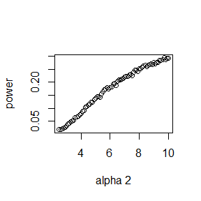

```r
set.seed(1107)
sk <- function(x) {
  #computes the sample skewness
  xbar <- mean(x)
  m3 <- mean((x - xbar)^3)
  m2 <- mean((x - xbar)^2)
  return(m3 / m2^1.5)
}
Powersktest1 <- function(a){
  n <- 20 #sample sizes
  cv <- qnorm(.975, 0, sqrt(6*(n-2)/(n+1)/(n+3)))
  #crit. values for each n
  p.reject <- numeric(length(a)) #to store sim. results
  m <- 10000 #num. repl. each sim.
  for (i in 1:length(a)) {
    sktests <- numeric(m) #test decisions
    for (j in 1:m) {
      x <- rbeta(n,2,a[i]) #test decision is 1 (reject) or 0
      sktests[j] <- as.integer(abs(sk(x)) >= cv)
      }
    p.reject[i] <- mean(sktests) #proportion rejected
    }
return(p.reject)
}
a <- seq(2.5,10,.1)
plot(cbind('alpha 2'=a,'power'=Powersktest1(a)))
```

We found that when $\alpha_{2}$ incereses, power increases. When $\alpha_{2}$ is up to 10, the power function is less than 0.3.

- 2. The population is t($v$).

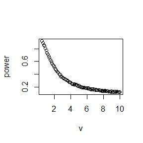

```r
Powersktest2 <- function(a2){
  a1 <- 2
  n <- 20 #sample sizes
  cv <- qnorm(.975, 0, sqrt(6*(n-2)/(n+1)/(n+3))) #crit. values for each n
  p.reject <- numeric(length(v)) #to store sim. results
  m <- 10000 #num. repl. each sim.
  for (i in 1:length(v)) {
    sktests <- numeric(m) #test decisions
    for (j in 1:m) {
      x <- rt(n,v[i]) #test decision is 1 (reject) or 0
      sktests[j] <- as.integer(abs(sk(x)) >= cv)
      }
    p.reject[i] <- mean(sktests) #proportion rejected
    }
return(p.reject)
}

v <- seq(0.5,10,.1)
plot(cbind(v,'power'=Powersktest2(v)))
```

- We found that when the t-distribution is between 4 and 10 degrees of freedom, power is around 0.2 and only when degrees of freedom are samll the power function is large.

## Solution 2 : The ieda comes from Ex 6.10.

- 1. In this example, we estimate by simulation the power of the skewness test of normality against a contaminatedbeta alternative. The contaminated beta distribution is denoted by $(1−\epsilon)Beta(\alpha=1,\beta=1)+\epsilon Beta(\alpha=500,\beta=500),0\le\epsilon\le1.$

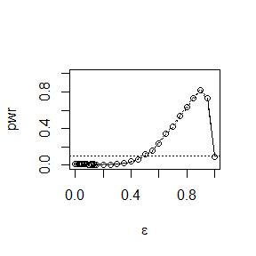

```r
alpha <- .1
n <- 30
m <- 2500
epsilon <- c(seq(0, .15, .01), seq(.15, 1, .05))
N <- length(epsilon)
pwr <- numeric(N) #critical value for the skewness test
cv <- qnorm(1-alpha/2, 0, sqrt(6*(n-2) / ((n+1)*(n+3))))
for (j in 1:N) {
  #for each epsilon
  e <- epsilon[j]
  sktests <- numeric(m)
  for (i in 1:m) {
    #for each replicate
    a <- sample(c(1, 500), replace = TRUE, size = n, prob = c(1-e, e))
    x <- rbeta(n, a, a)
    sktests[i] <- as.integer(abs(sk(x)) >= cv)
    }
  pwr[j] <- mean(sktests) }
#plot power vs epsilon
plot(epsilon, pwr, type = "b", xlab = bquote(epsilon), ylim = c(0,1))
abline(h = .1, lty = 3)
se <- sqrt(pwr * (1-pwr) / m)
#add standard errors
lines(epsilon, pwr+se, lty = 3)
lines(epsilon, pwr-se, lty = 3)
```

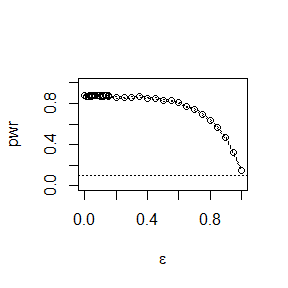

```r
alpha <- .1
n <- 30
m <- 2500
epsilon <- c(seq(0, .15, .01), seq(.15, 1, .05))
N <- length(epsilon)
pwr <- numeric(N) #critical value for the skewness test
cv <- qnorm(1-alpha/2, 0, sqrt(6*(n-2) / ((n+1)*(n+3))))
for (j in 1:N) {
  #for each epsilon
  e <- epsilon[j]
  sktests <- numeric(m)
  for (i in 1:m) {
    #for each replicate
    v <- sample(c(1, 20), replace = TRUE, size = n, prob = c(1-e, e))
    x <- rt(n, v)
    sktests[i] <- as.integer(abs(sk(x)) >= cv)
    }
  pwr[j] <- mean(sktests) }
#plot power vs epsilon
plot(epsilon, pwr, type = "b", xlab = bquote(epsilon), ylim = c(0,1))
abline(h = .1, lty = 3)
se <- sqrt(pwr * (1-pwr) / m)
#add standard errors
lines(epsilon, pwr+se, lty = 3)
lines(epsilon, pwr-se, lty = 3)
```